# ACP - TP *correction*

## Données

Nous utilisons les données de température mondiale **HadCRUT4**, fournies par [Climate Research Unit](https://crudata.uea.ac.uk/). C’est l’historique des anomalies moyennes mensuelles et annuelles depuis 1850, au niveau mondial, par rapport à la période de référence 1961-1990.

Nous voyons dans le graphique ci-dessous que les anomalies augmentent continuellement sur la période, particulièrement à partir des années 1980.

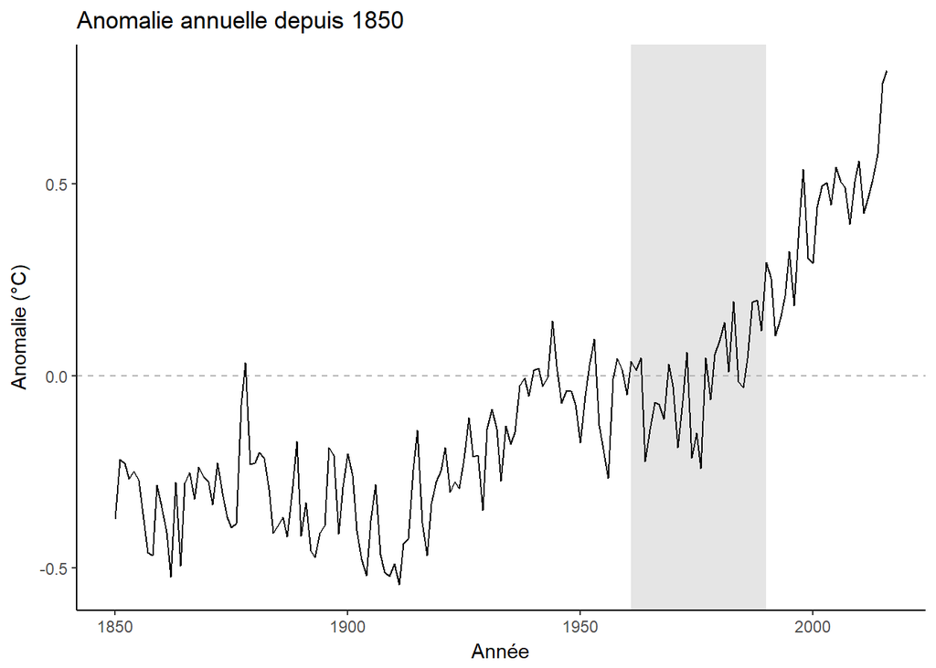

Il ne semble pas y avoir, entre les mois, de différences flagrantes de comportement (cf graphique ci-dessous). Les mois de mai à septembre semblent avoir moins de variabilité que les autres.

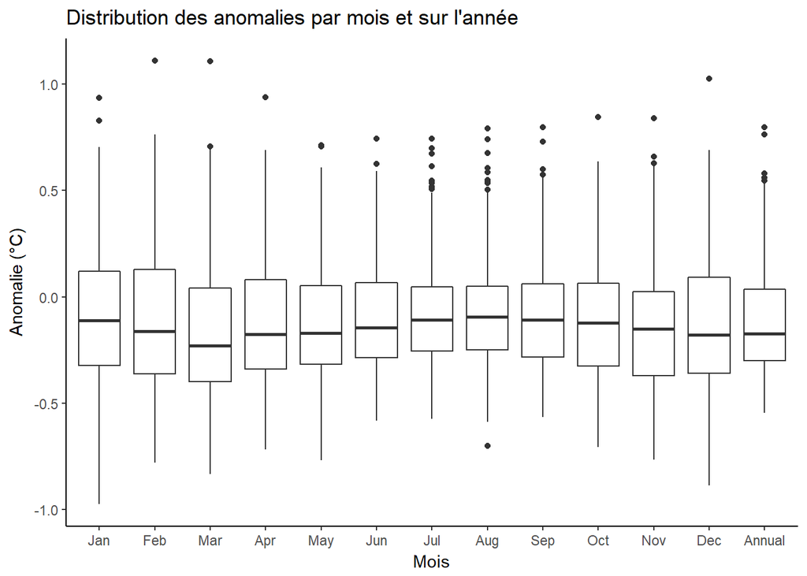

Dans le graphique ci-dessous, nous remarquons bien que les variances sont très proches d’un mois à l’autre.

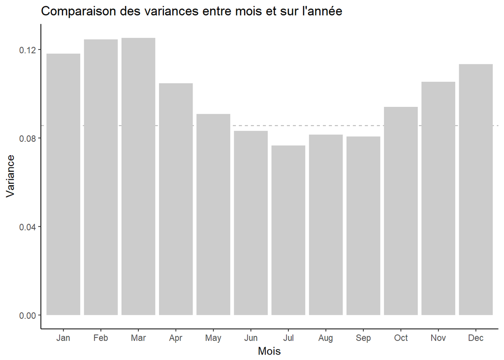

Il est aussi intéressant de noter la corrélation entre les mois (ci ci-dessous). Nous remarquons que, même si globalement les mois sont tous corrélés entre eux (aucune corrélation inférieure à 0.7), ils le sont plutôt avec les mois proches (par exemple janvier et février).

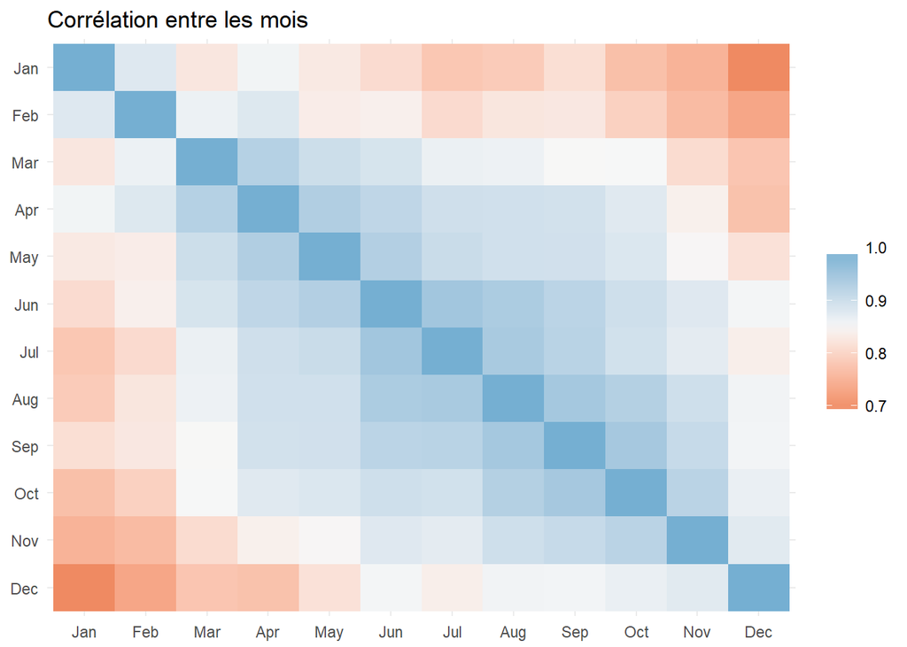

## ACP

Au vu de la description des données ci-dessous, **nous utiliserons donc une ACP centrée dans la suite du travail.**

[output not shown]

L’analyse graphique de la variance expliquée simple et cumulée nous donne la même conclusion : nous ne retiendrons que deux axes.

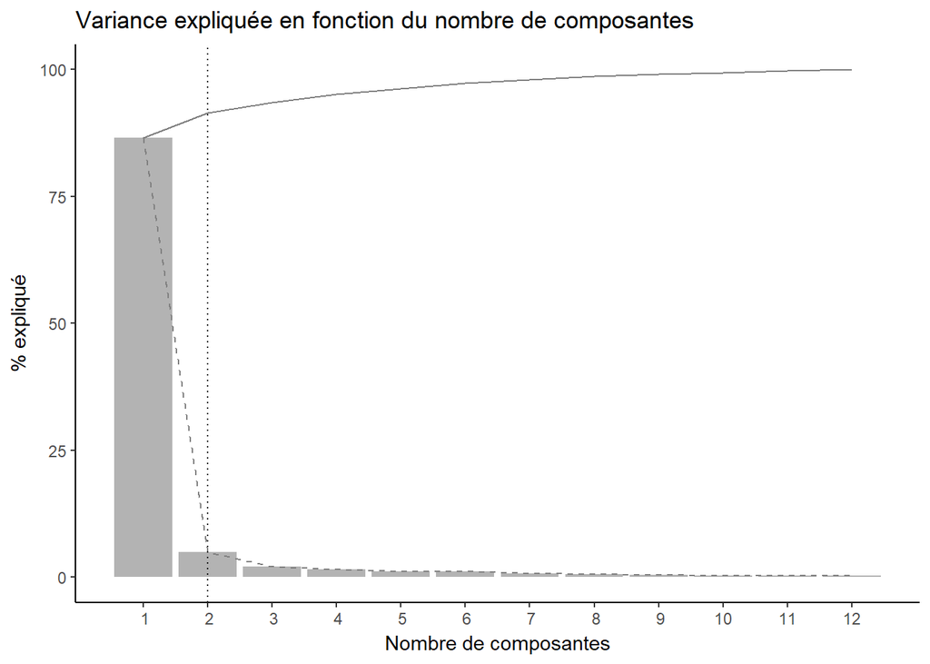

Sur le premier plan factoriel des variables, dans le graphique ci-dessous, nous voyons que toutes les variables (mois) sont sur la droite. Le premier axe va donc séparer les anomalies à forte valeur à droite, avec les anomalies à faible valeur à gauche. Nous pouvons en conclure que cette axe nous renseignera la température d’une année :

- les années représentées à droite seront des années chaudes,
- les années à gauche du graphique seront donc des années froides.

Tout ceci par rapport à la période de référence 1961-1990 bien évidemment.

Le second axe semble lui opposé les mois de début d’année, dans la partie basse, aux mois de fin d’année, dans la partie haute, avec une progression linéaire entre janvier et décembre. Nous retrouvons ici les corrélations entre mois déjà aperçues plus haut.

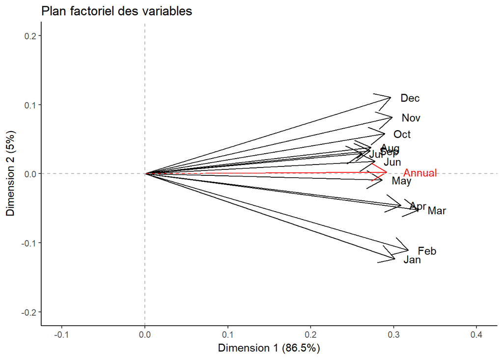

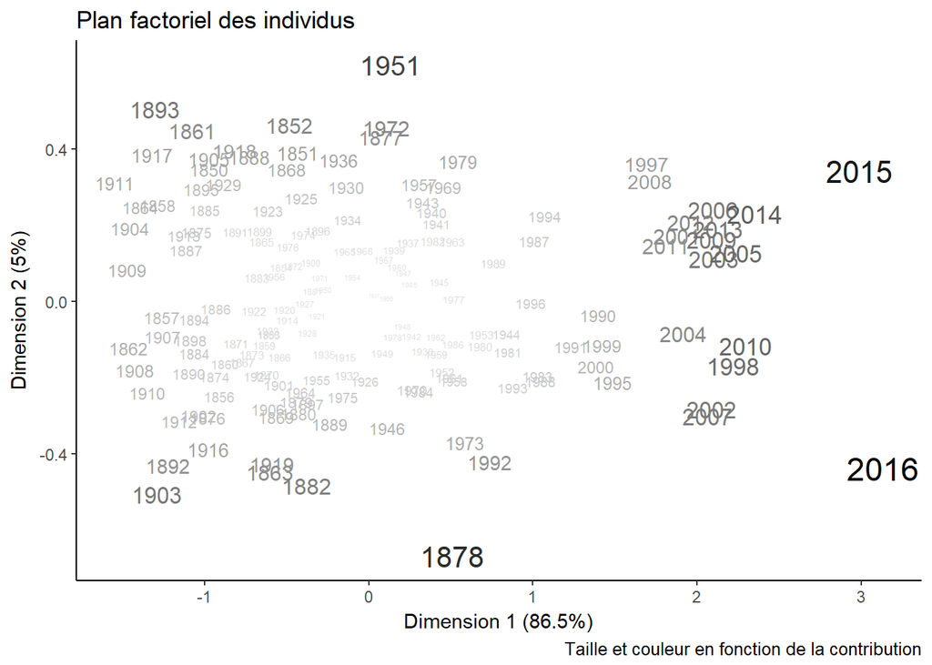

## ACP avec individus supplémentaires identifiés

Les pourcentages de variance expliquée sont très proches de la première ACP. Par contre, plus aucune composante n’a une valeur propre supérieure à 1.

[output not shown]

Et la projection des variables sur le premier plan factoriel, dans le graphique ci-dessous, nous amène aux même conclusions.

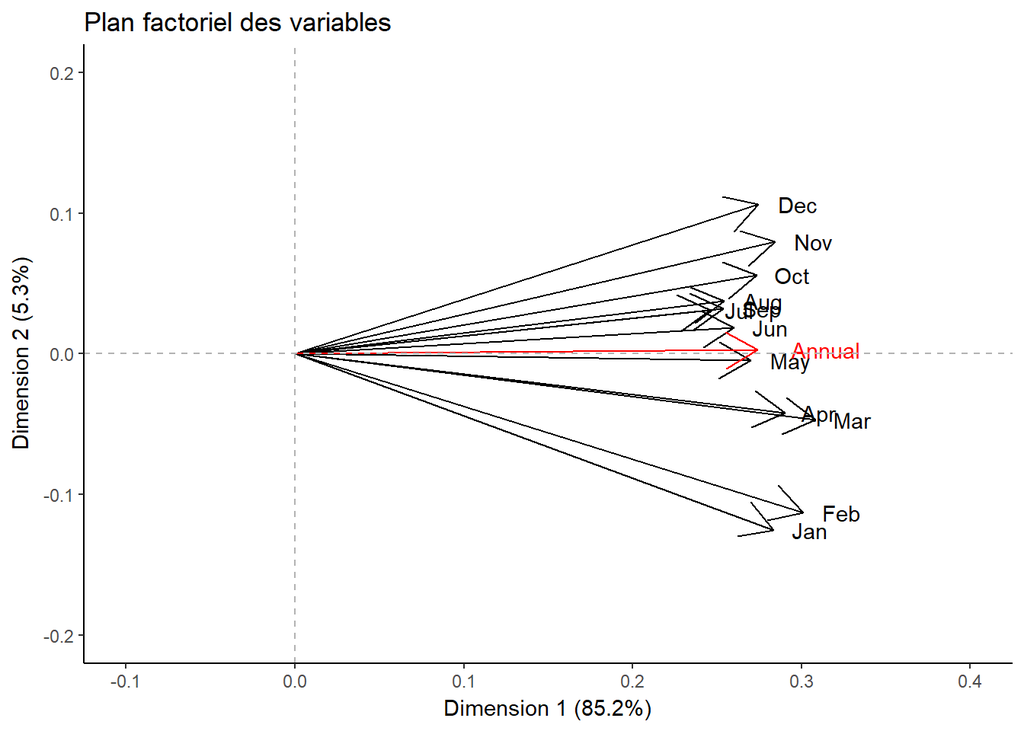

Il n’y a pas de différences claires entre les deux, si ce n’est l’absence de valeur propre supérieure à 1.